# STA 141A Project 2

Ally Deremer, Eshna Prakash, Jose Lopez, Jasper Cheng

3/5/2021

# Introduction

The dataset utilized in this study is from the World Health Organization (WHO) in the format of an excel file that is updated on a daily basis. The data set contains information about COVID-19 cases for each of the 237 countries data was collected from. Data collection began January 3, 2020 and this report uses all data collected until March 1, 2021. The number of new cases, cumulative cases, new deaths and cumulative deaths are recorded for each day of data collection. The hypotheses this report will focus on is that Case Fatality Rate will vary across different countries.

# Background

Coronavirus is a highly contagious respiratory illness which is also known as COVID-19. This virus spreads through droplets in the air when an infected person coughs or sneezes. There is no specific treatment for the virus and laboratory tests are required for confirmation of diagnosis. While most recover from COVID-19, some have symptoms that last for weeks or even months after recovering from acute illness. The long term effects of COVID-19 are not currently known and it is being investigated. Those with a higher risk of dying from COVID-19 and related complications are older people and those with underlying medical conditions. Prevention measures that can be taken against this virus include wearing facial coverings, frequent washing of hands and social distancing. Currently, there is an increase in global coronavirus cases which may be due to public health restrictions being lifted in addition to new coronavirus variants.(WHO, 2021). Multiple vaccines have been developed for emergency use and over 245 million doses have been administered in 107 countries.

Case Fatality Rate (CFR) is all deaths from the specific disease in the population divided by all cases of the disease in the population. It is important to note that CFR is not an accurate measure of the mortality risk of the disease during a pandemic.

# Descriptive Analysis

This report will not analyze every country from the WHO data set. The WHO regions include African Region (AFR), Regions of the Americas (AMR), South East Asian Region (SEAR), European Region (EUR), Eastern Mediterranean Region (EMR) and the Western Pacific Region (WPR). This report chose the two most populated countries for each WHO region. Therefore, this report looks at Nigeria, Ethiopia, US, Brazil, India, Indonesia, Russia, Turkey, Pakistan, Egypt, China and Japan. The time period selected to focus on was the 100 days after the 100th confirmed case of COVID-19. The purpose for this was to restrict the data set to verify all countries had at least 100 confirmed coronavirus cases to avoid influencing results due to small numbers. (Sorci, Faivre, & Morand, 2020)

```
## [1] "ï..Date_reported"  "Country_code"      "Country"
## [4] "WHO_region"        "New_cases"         "Cumulative_cases"
## [7] "New_deaths"        "Cumulative_deaths" "CFR"
```

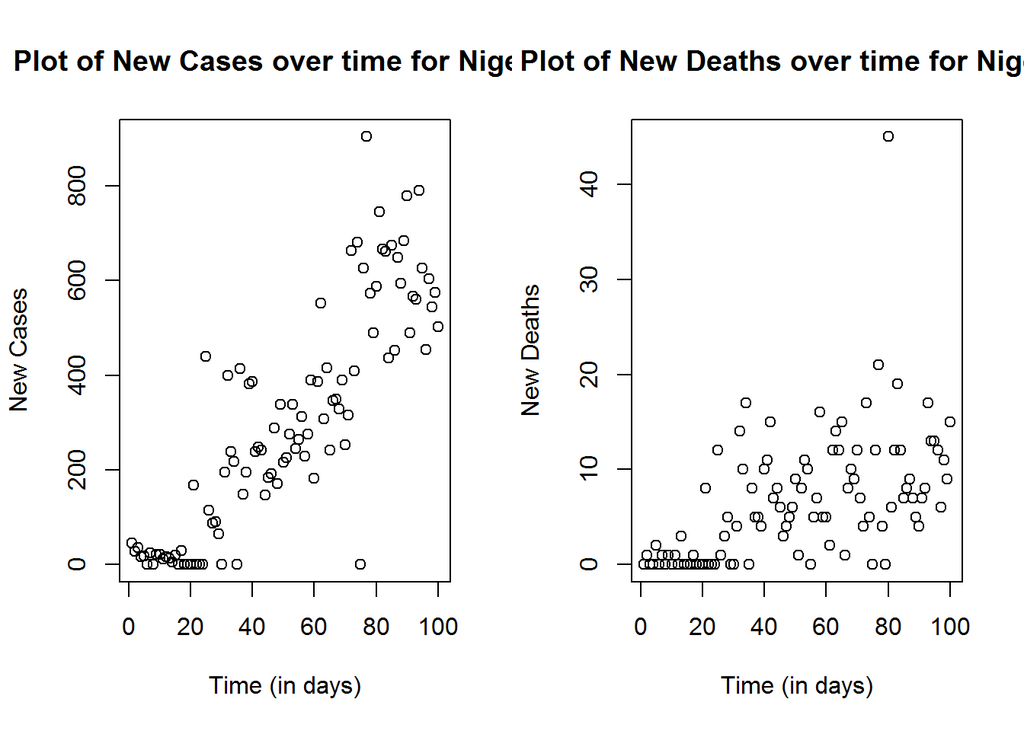

Plots for Ethiopia are shown below. Plot of new cases does not appear to be linear but has a positive trend. Plot of new deaths appears to have a positive trend of new deaths as time increases.

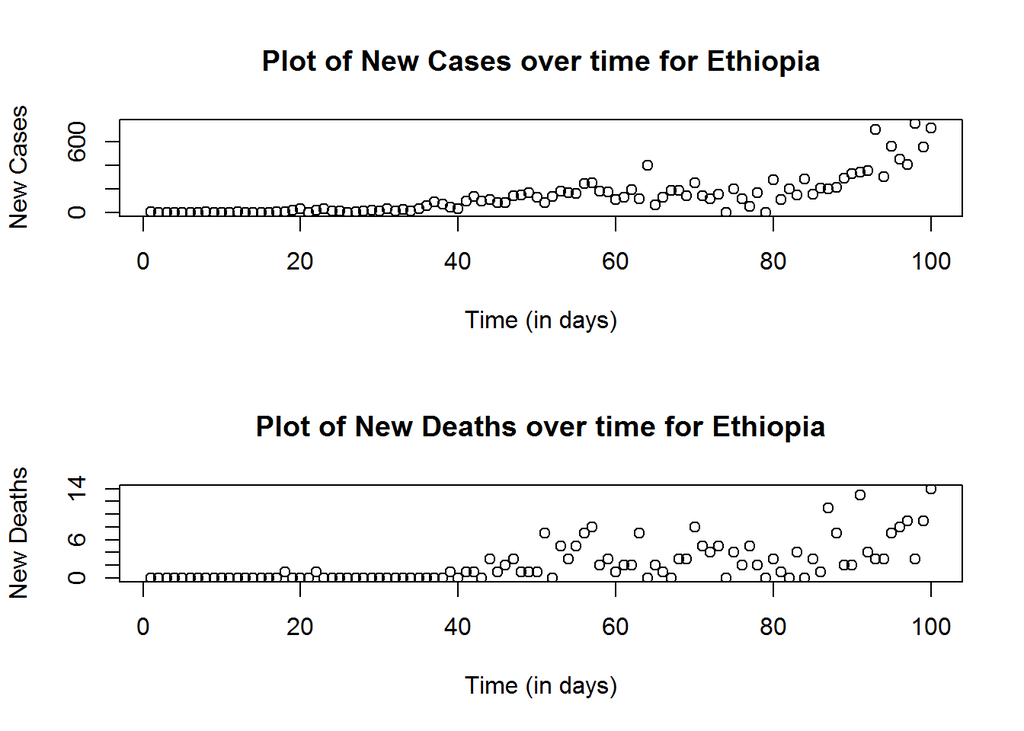

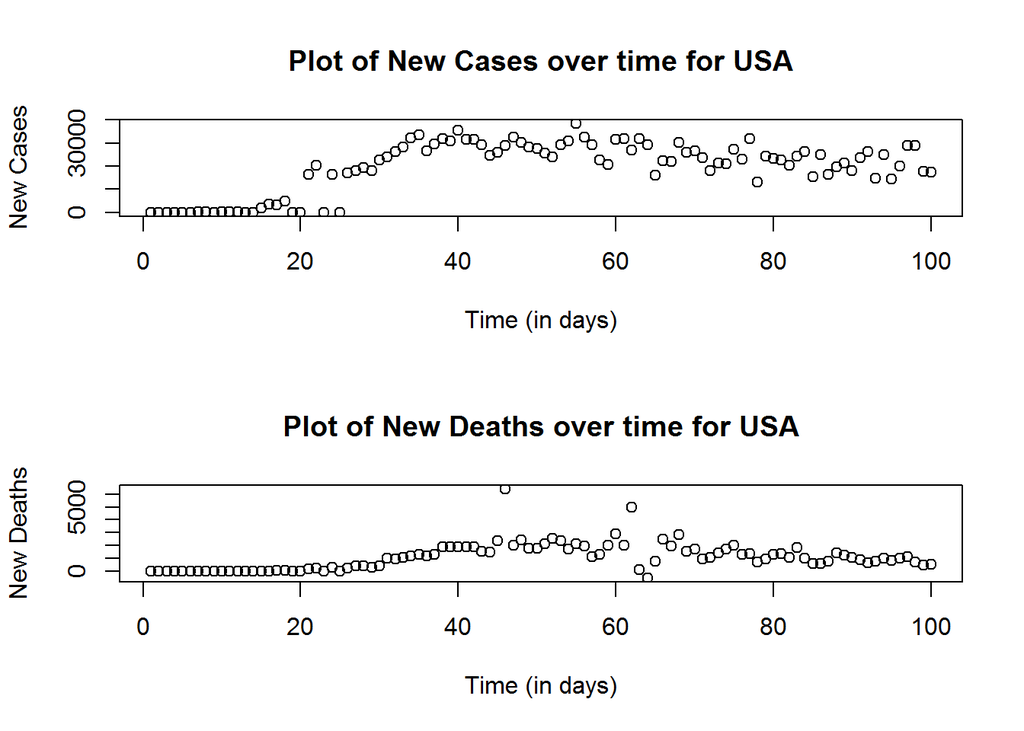

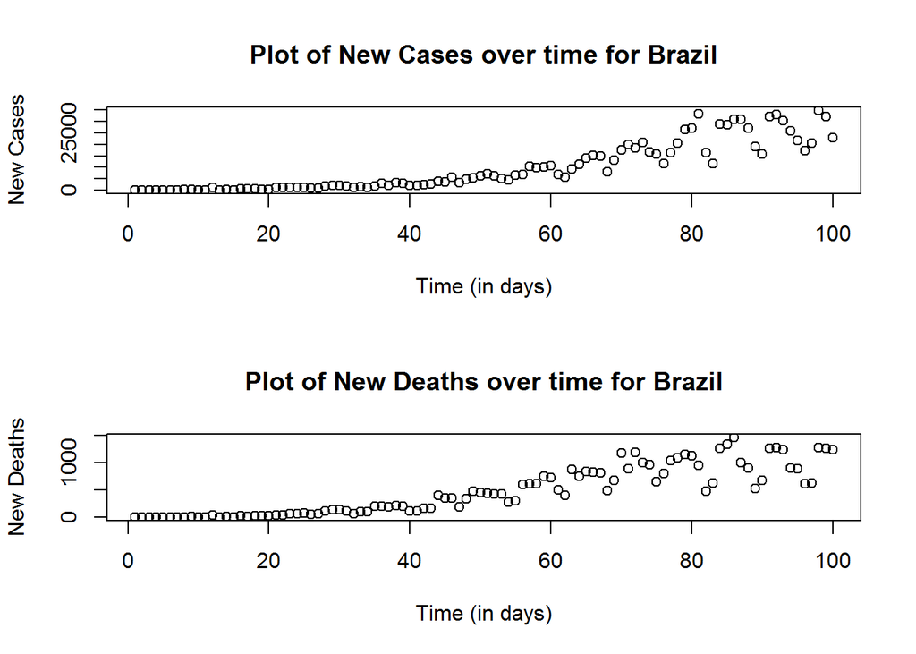

Plots for India are shown below. There is a positive trend that appears to be linear for new cases. There appears to be a positive linear trend with a few possible outliers present for new deaths over time.

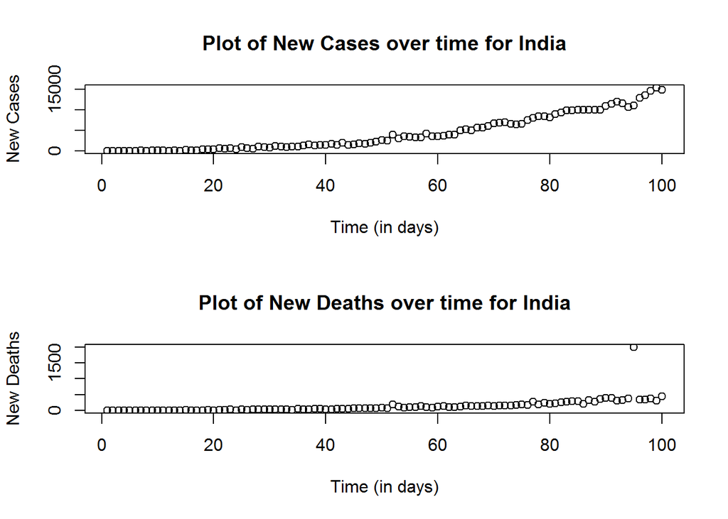

Plots for Indonesia are shown below. For new cases over time, it appears that there is a positive linear trend. For new deaths over time, there appears to be a slight positive linear trend with a few possible outliers.

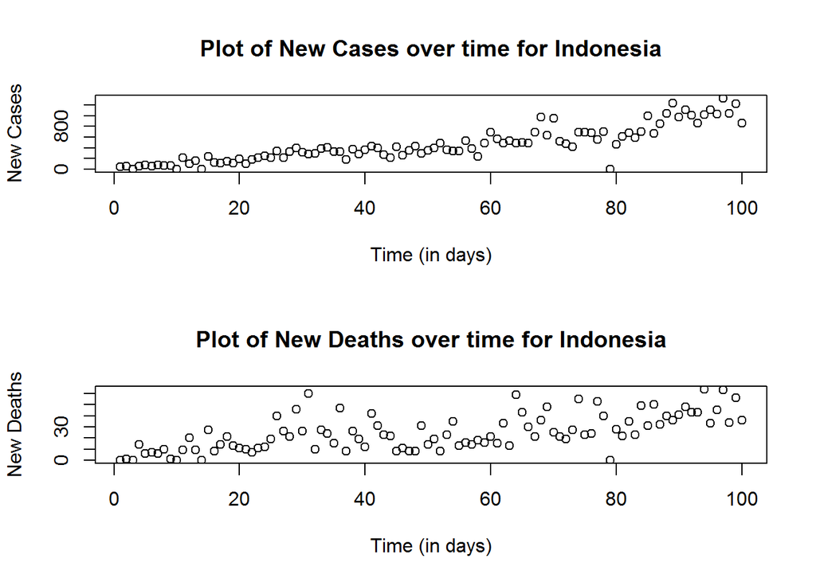

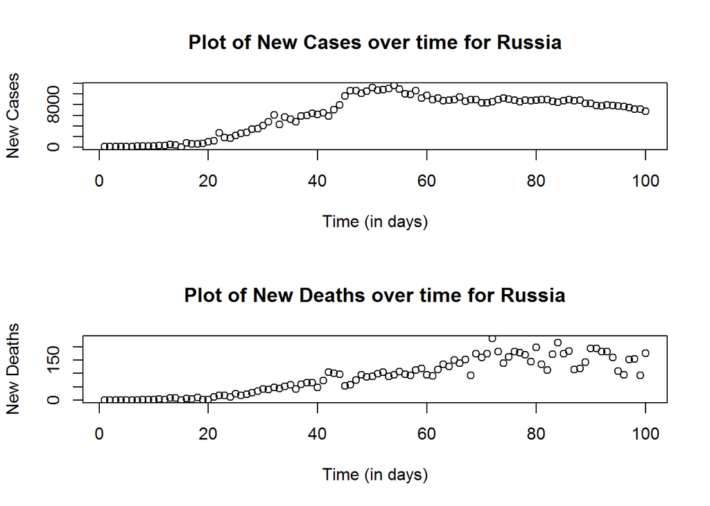

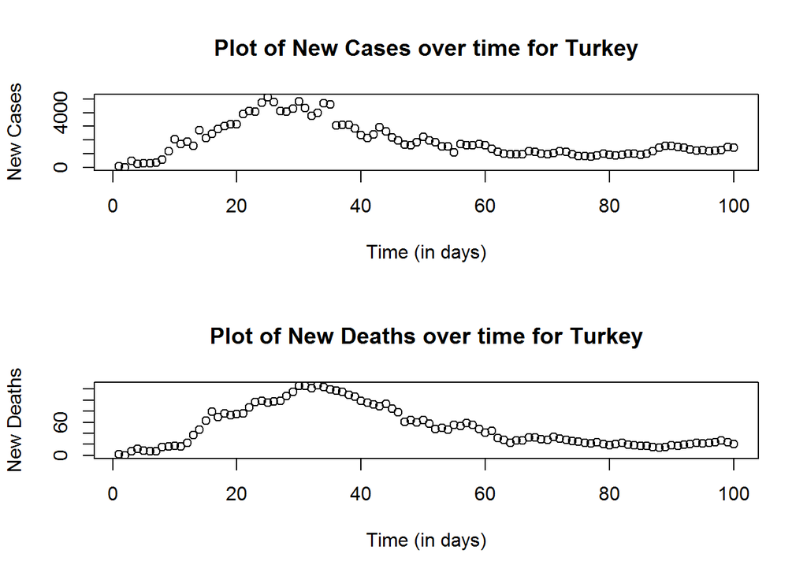

Plots for Pakistan are shown below. It is evident that there is no linear trend for both new cases over time and new deaths over time.

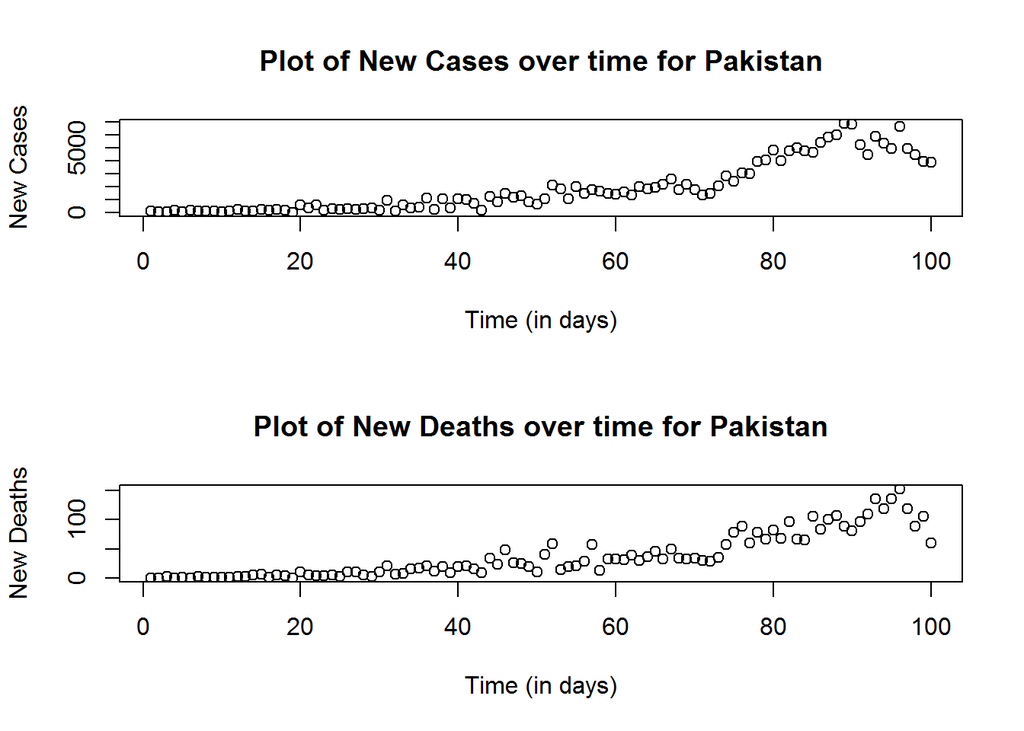

Plots for Egypt are shown below. For both plots, it is evident that there is not a linear trend.

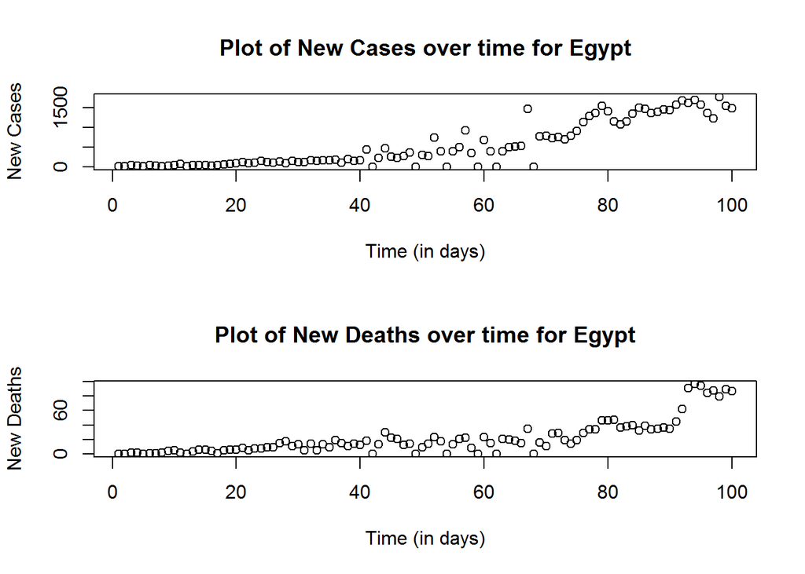

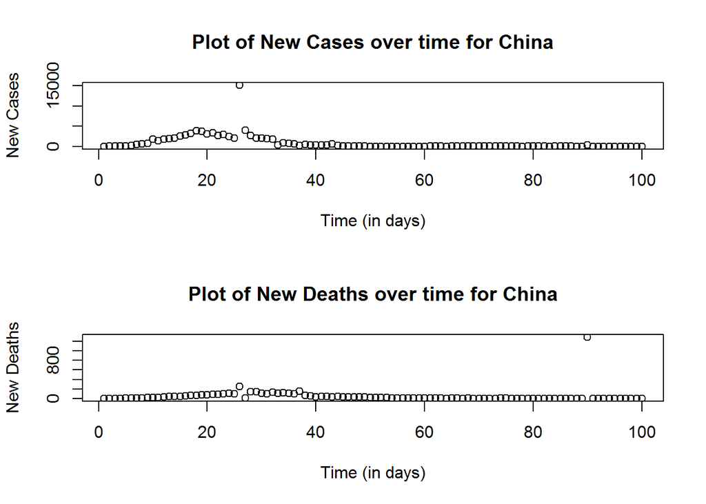

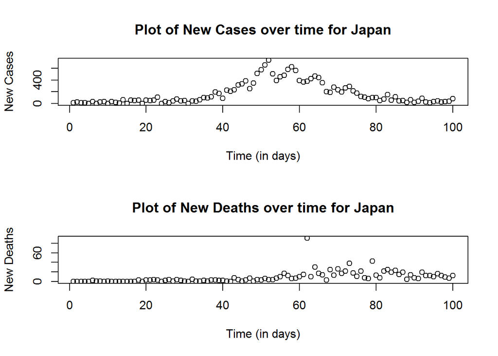

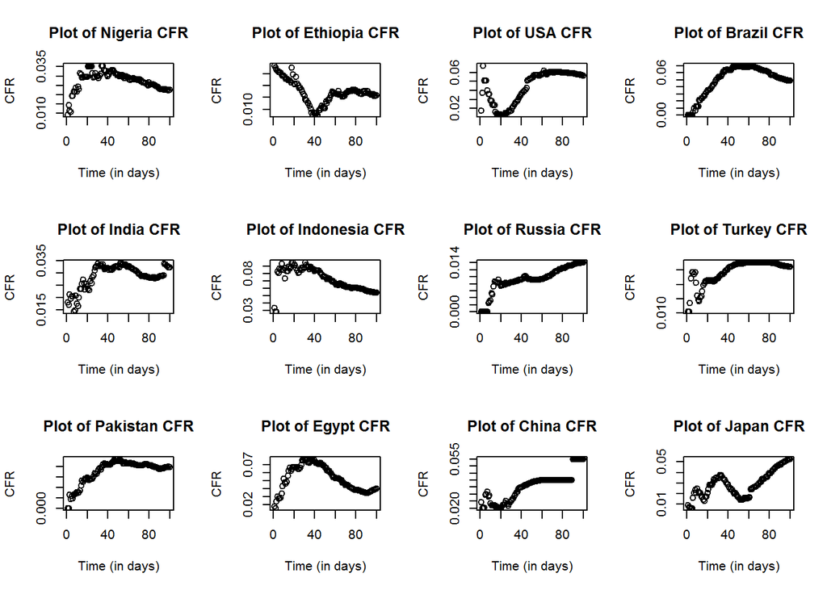

# Statistical Approach

For statistical analysis, regression modeling will be employed. Through the descriptive analysis, it has been learned that data points are scattered mostly in a non-linear faction across every country under observation. Therefore, polynomial regression will be fitted according to human intuition. As it is known, there is a trade off between variance and bias for polynomial regression. While a high degree regression may represent every data point accurately, it does not necessarily reflect a meaningful trend and is incomparable to other regressions. Hence, the degree of polynomial regression is considered under a low bias, low variance basis, instead of sacrificing one for the other.

##Nigeria Model

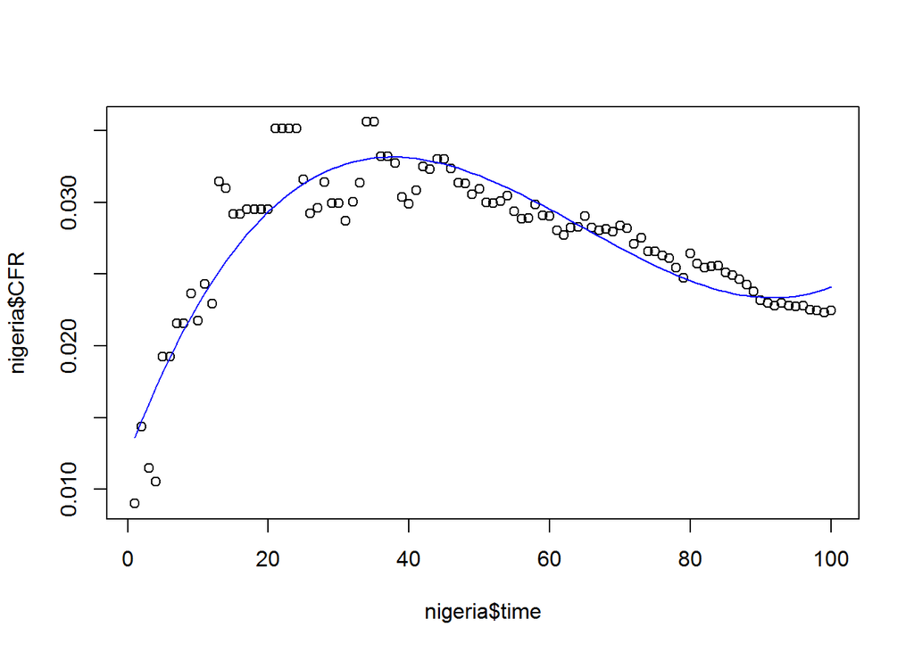

```r
#For Nigeria
nigeria2= lm(nigeria$CFR~poly(nigeria$time, degree=3, raw=TRUE))
plot(nigeria$time, nigeria$CFR)
lines(smooth.spline(nigeria$time,predict(nigeria2)),col='blue')
```

##Ethiopia Model

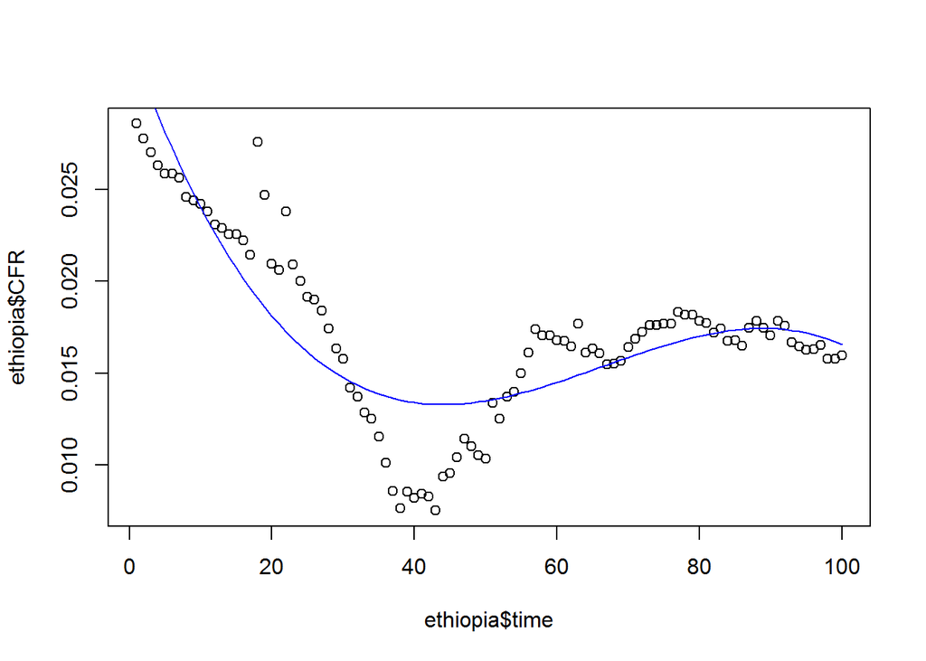

```r
#For Ethiopia
ethiopia2= lm(ethiopia$CFR~poly(ethiopia$time, degree=3, raw=T))
#stuck between choosing 3 or 4, 3 is more logical of a trend(leaning towards 3), 4 is more fitting and better sensitivity analysis
plot(ethiopia$time, ethiopia$CFR)
lines(smooth.spline(ethiopia$time,predict(ethiopia2)),col='blue')
```

##USA Model

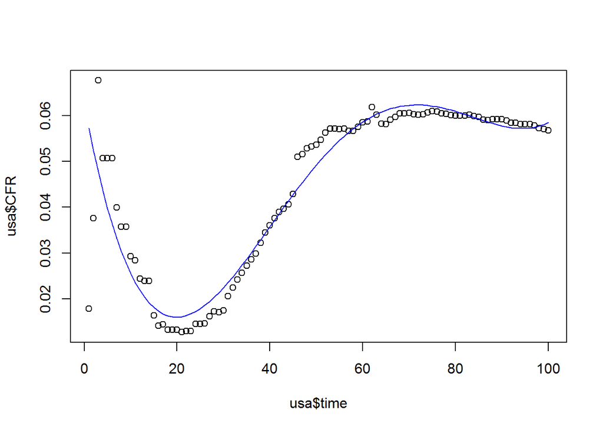

```r
#For US
us2= lm(usa$CFR~poly(usa$time, degree=4, raw=T))

plot(usa$time, usa$CFR)
lines(smooth.spline(usa$time,predict(us2)),col='blue')
```

##Brazil Model

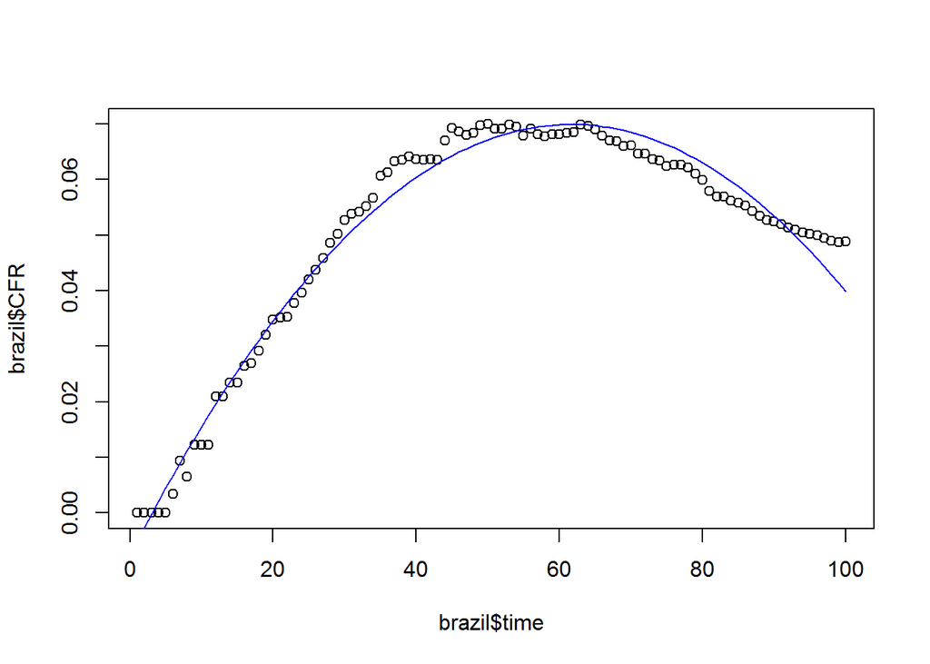

```r
#For Brazil
brazil2= lm(brazil$CFR~poly(brazil$time, degree=2, raw=T))
plot(brazil$time, brazil$CFR)
lines(smooth.spline(brazil$time,predict(brazil2)),col='blue')
```

##India Model

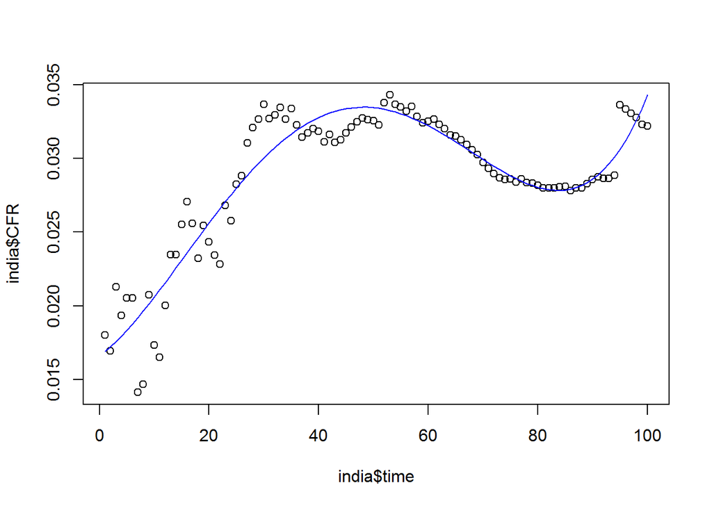

```r
#For India
india2= lm(india$CFR~poly(india$time, degree=4, raw=T))
plot(india$time, india$CFR)
lines(smooth.spline(india$time,predict(india2)),col='blue')
```

##Indonesia Model

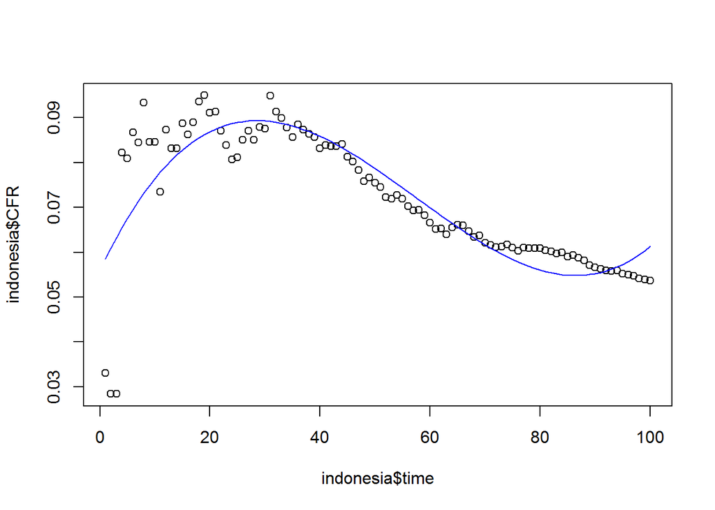

```r
#For Indonesia
indonesia2= lm(indonesia$CFR~poly(indonesia$time, degree=3, raw=T))
plot(indonesia$time, indonesia$CFR)
lines(smooth.spline(indonesia$time,predict(indonesia2)),col='blue')
```

##Pakistan Model

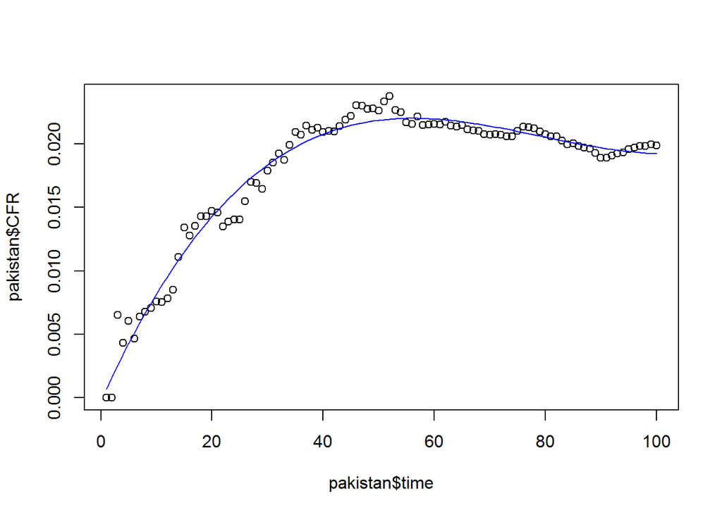

```r
#For Pakistan
pakpoly.model = lm(CFR~ poly(time, degree = 3 , raw = TRUE), data = pakistan)
plot(pakistan$time, pakistan$CFR)
lines(smooth.spline(pakistan$time,predict(pakpoly.model)),col='blue')
```

##Russia Model

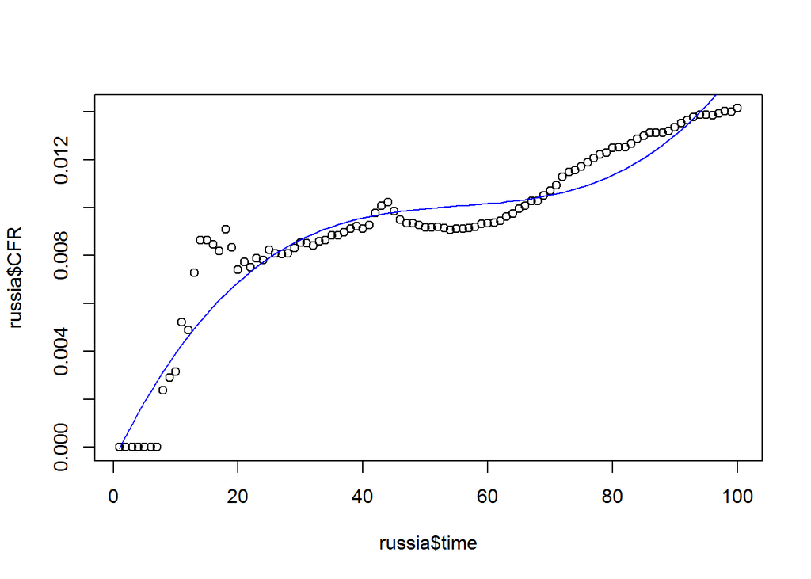

```r
#For Russia
russpoly.model = lm(CFR~ poly(time, degree = 3, raw = TRUE), data = russia)

plot(russia$time, russia$CFR)
lines(smooth.spline(russia$time,predict(russpoly.model)),col='blue')
```

##Turkey Model

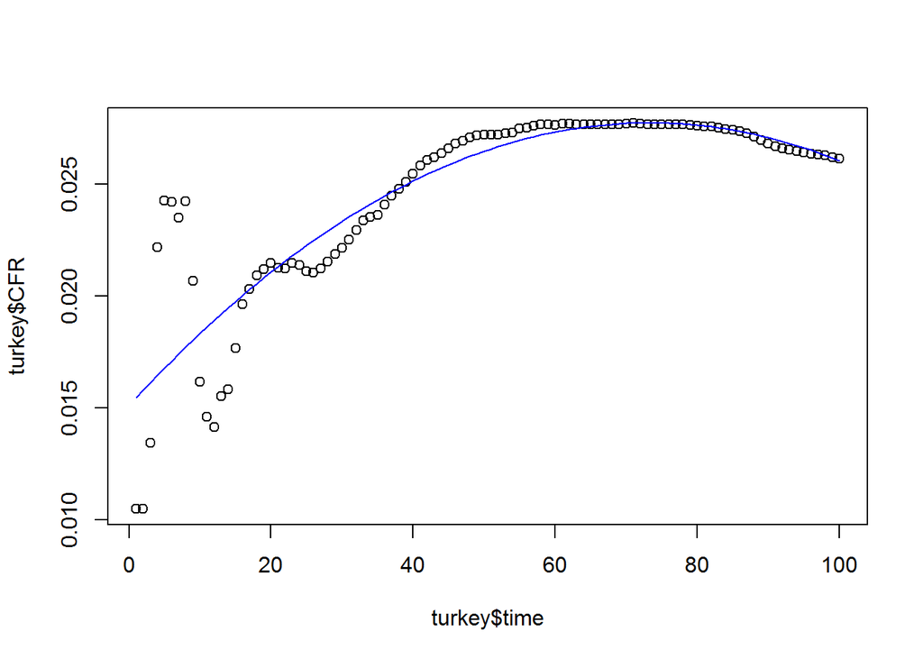

```r
#For Turkey
turkpoly.model = lm(CFR~ poly(time, degree = 2, raw = TRUE), data = turkey)
plot(turkey$time, turkey$CFR)
lines(smooth.spline(turkey$time,predict(turkpoly.model)),col='blue')
```

##Egypt Model

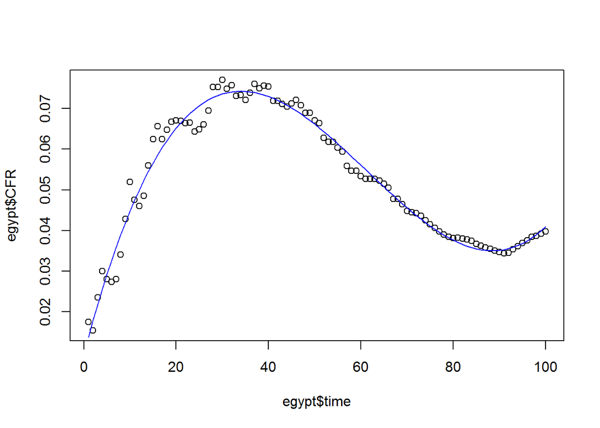

```r
#For Egypt (choose 3, mod 2 only for comparison)
modegypt3=lm(CFR~poly(time,degree=3,raw=T), data = egypt)

plot(egypt$time,egypt$CFR)
lines(smooth.spline(egypt$time,predict(modegypt3)),col='blue')
```

##Japan Model

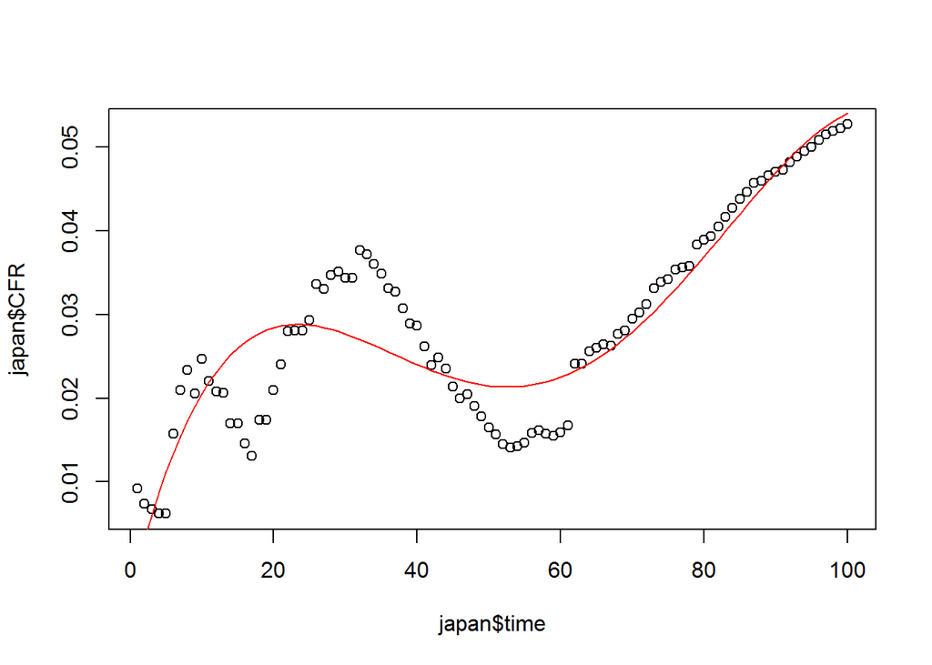

```r
#For Japan
modjapan2=lm(japan$CFR~poly(japan$time,degree=4,raw=T))

plot(japan$time,japan$CFR)
lines(smooth.spline(japan$time,predict(modjapan2)),col='red')
```

##China Model

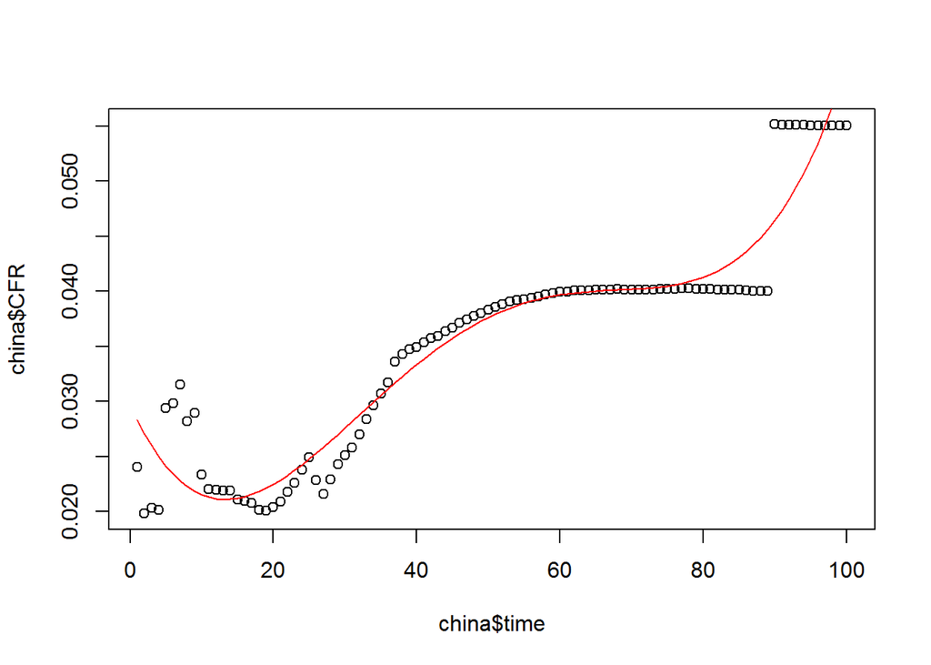

```r
#For China (since the outliers are quite extreme, you guys could make a decision on what to do)

modchina2=lm(china$CFR~poly(china$time,degree=4,raw=T))

plot(china$time,china$CFR)
lines(smooth.spline(china$time,predict(modchina2)),col='red')
```

# Results

For an actual answer to our question of interest, there will be two approaches to reach suitable results: ANOVA, and confidence bands.

In the following ANOVA models, data across all 12 countries will be fit into a regression of a certain polynomial, the same data set will then be fit into the same level of polynomial but with regards to each country. ANOVA will attempt to compare the two regression models to prove if country does have an effect on CFR over time.

Since this type of ANOVA model can only use one chosen degree of polynomials, the third and fourth degree will be tested since they are the most common regressions fitted above.

```r
binddata = rbind(nigeria,ethiopia,usa,brazil,india,indonesia,russia,turkey,pakistan,egypt,china,japan)

fit0 <- lm(CFR ~ poly(time, 3), data = binddata)
fit1 <- lm(CFR ~ poly(time, 3)*Country, data = binddata)

anova(fit0,fit1)
```

```
## Analysis of Variance Table
##
## Model 1: CFR ~ poly(time, 3)
## Model 2: CFR ~ poly(time, 3) * Country
##   Res.Df     RSS Df Sum of Sq      F    Pr(>F)
## 1   1196 0.48026
## 2   1152 0.01970 44   0.46057 612.15 < 2.2e-16 ***
## ---
## Signif. codes:  0 '***' 0.001 '**' 0.01 '*' 0.05 '.' 0.1 ' ' 1
```

```r
fit3 <- lm(CFR ~ poly(time, 4), data = binddata)
fit4 <- lm(CFR ~ poly(time, 4)*Country, data = binddata)

anova(fit3,fit4)
```

```
## Analysis of Variance Table
##
## Model 1: CFR ~ poly(time, 4)
## Model 2: CFR ~ poly(time, 4) * Country
##   Res.Df     RSS Df Sum of Sq      F    Pr(>F)
## 1   1195 0.48026
## 2   1140 0.01311 55   0.46715 738.38 < 2.2e-16 ***
## ---
## Signif. codes:  0 '***' 0.001 '**' 0.01 '*' 0.05 '.' 0.1 ' ' 1
```

As shown, the p-value is extremely low for both comparisons. This means that country does have an strong statistical effect on CFR over time for both regressions of third and fourth degree.

# Sensitivity Analysis

##Nigeria Plots

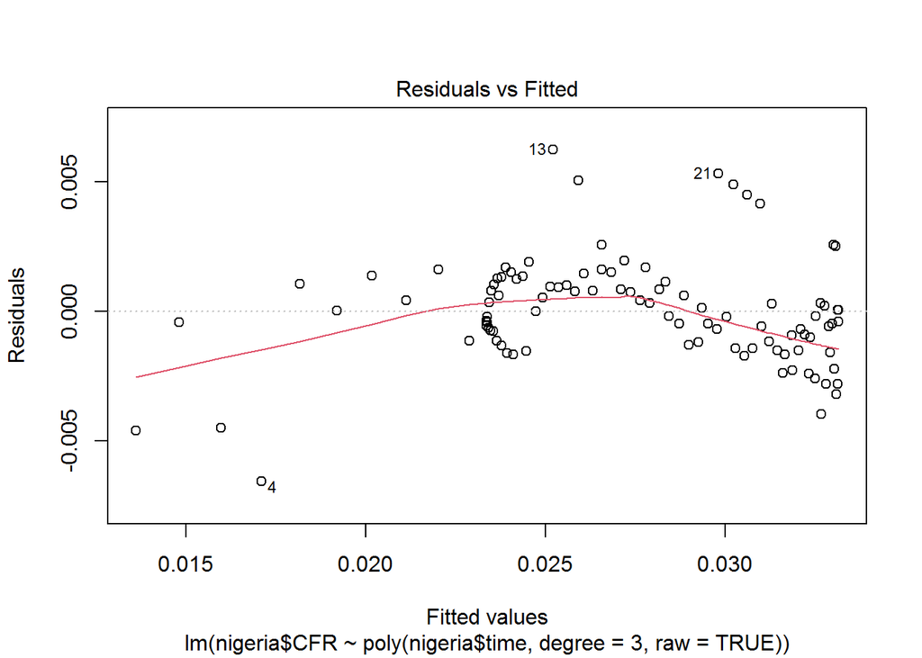

```r
nigeriaresid = plot(nigeria2,1)
```

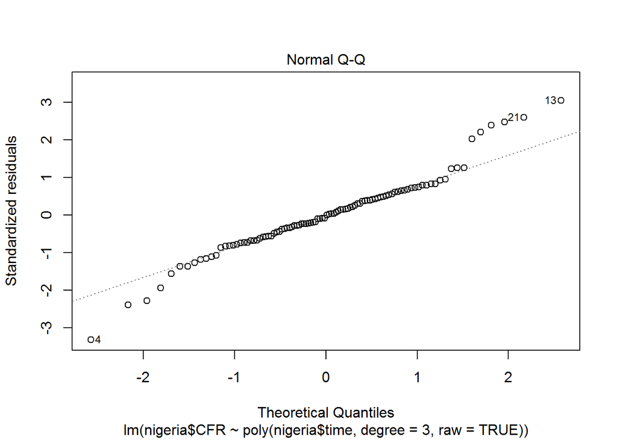

```r
nigeriaqq = plot(nigeria2, 2)
```

##Ethiopia Plots

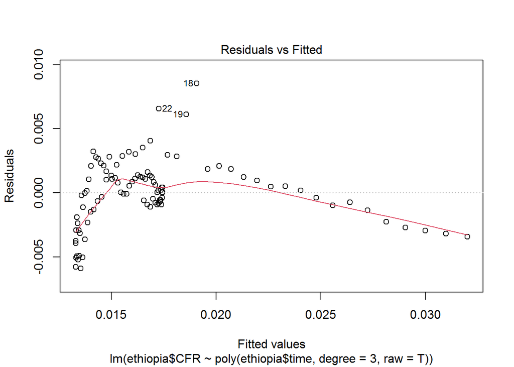

```r
ethiopiaresid = plot(ethiopia2,1)
```

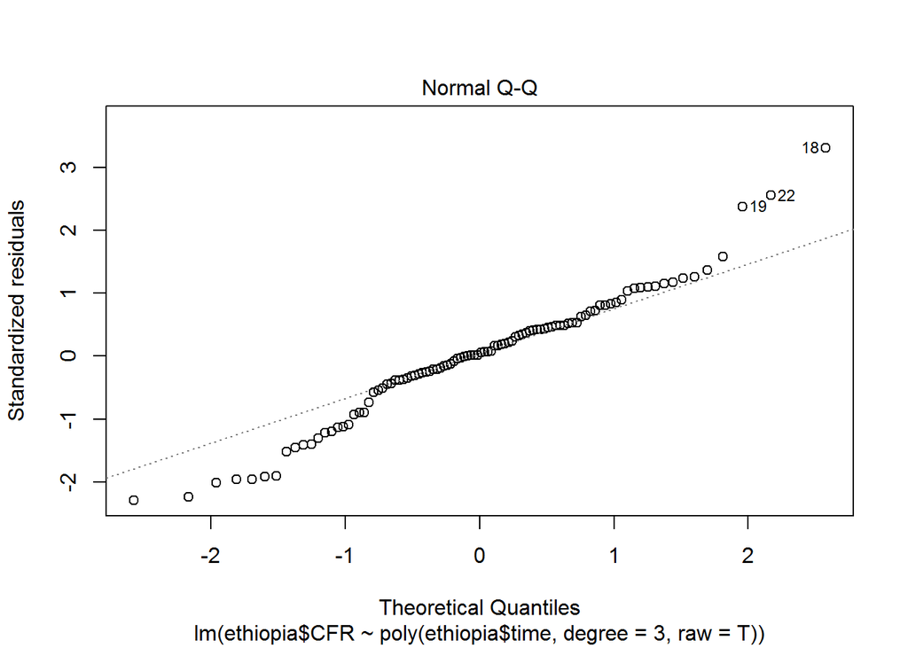

```r
ethiopiaqq = plot(ethiopia2,2)
```

##USA Plots

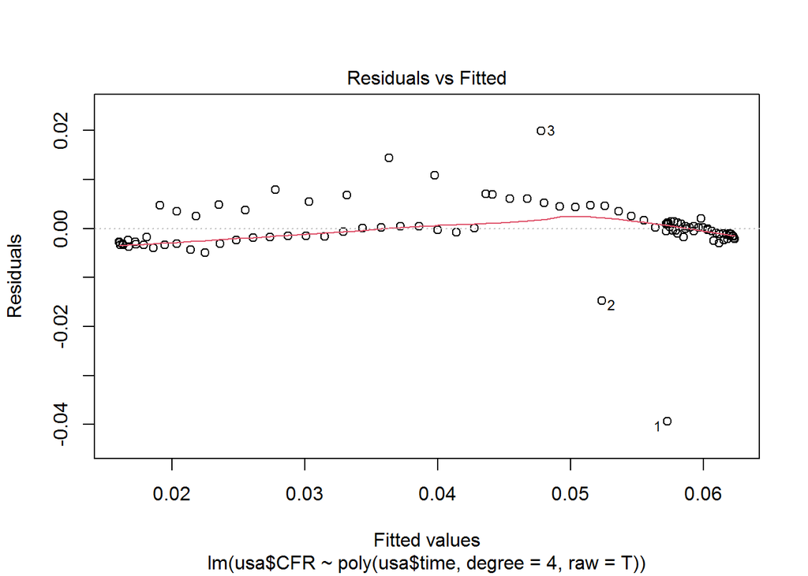

```r
usaresid = plot(us2,1)
```

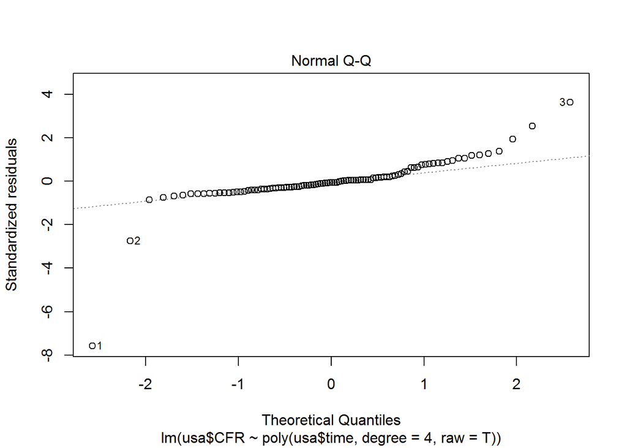

```r
usaqq = plot(us2,2)
```

##Brazil Plots

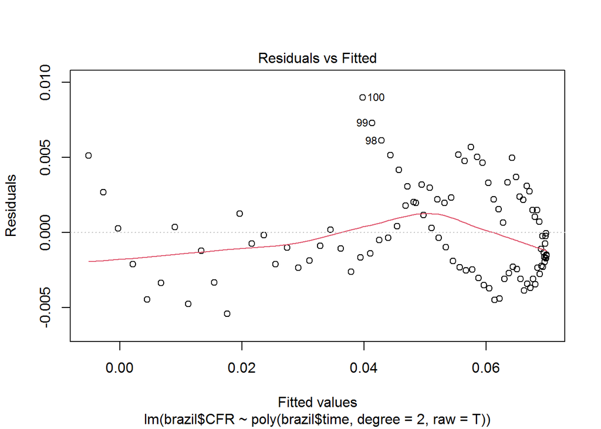

```r
brazilresid = plot(brazil2,1)
```

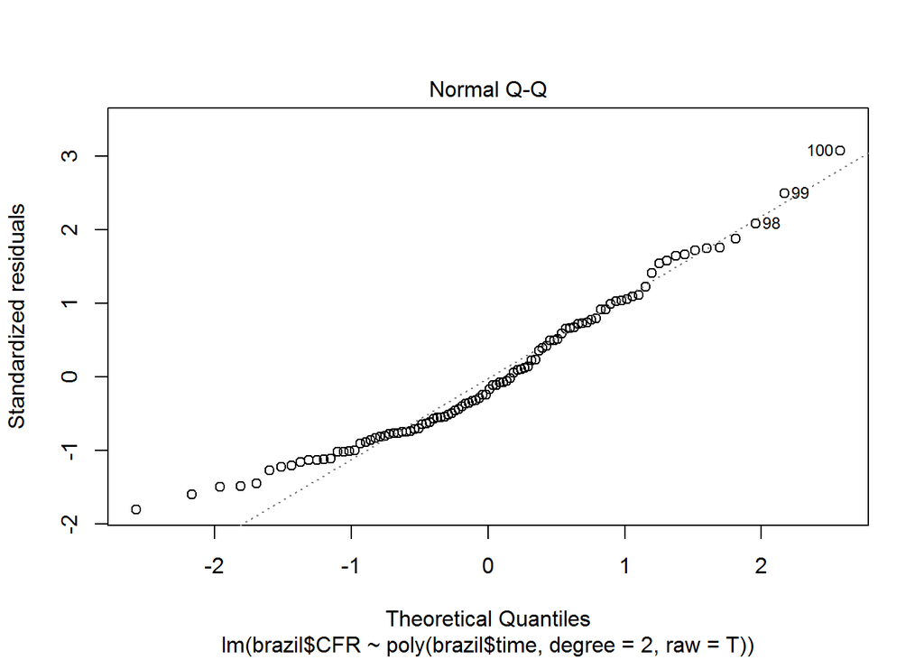

```r
brazilqq = plot(brazil2,2)
```

##India Plots

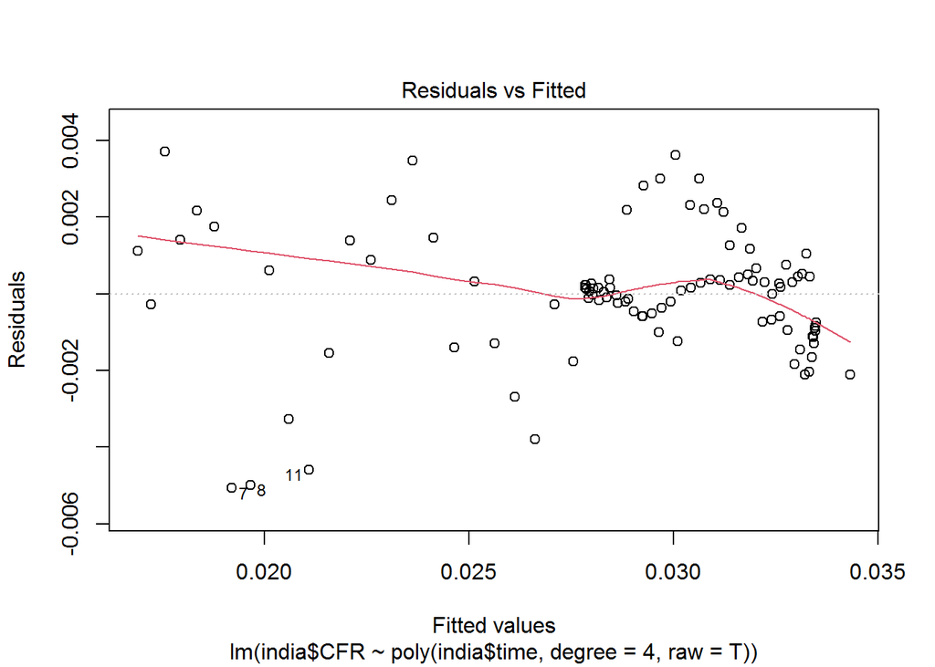

```r
indiaresid = plot(india2,1)
```

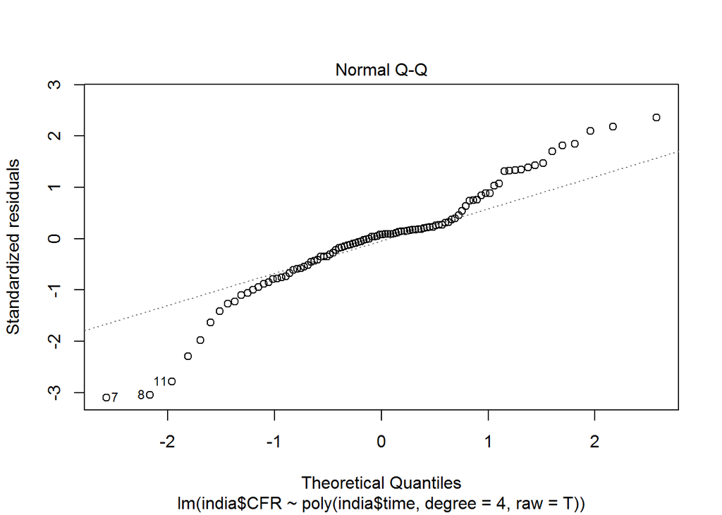

```r
indiaqq = plot(india2,2)
```

##Indonesia Plots

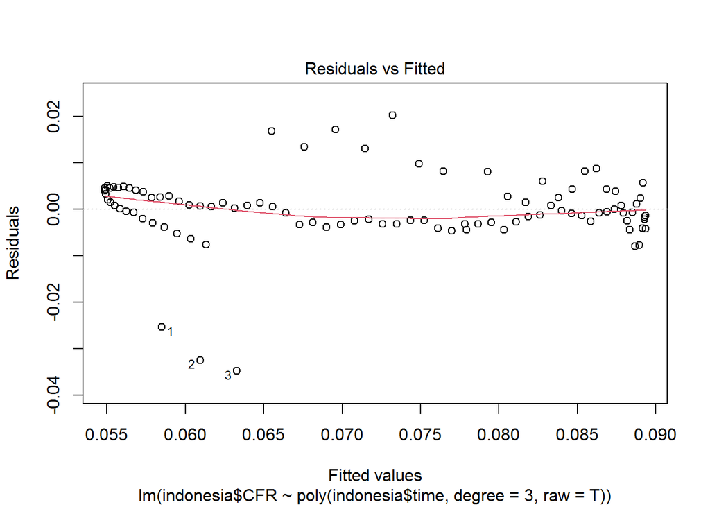

```r
indonesiaresid = plot(indonesia2,1)
```

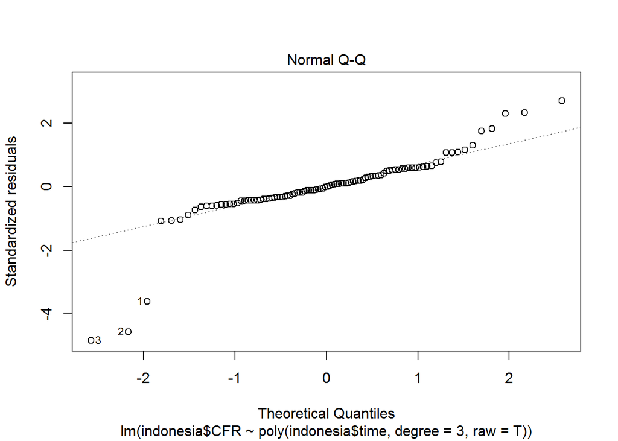

```r
indonesiaqq = plot(indonesia2,2)
```

##Russia Plots

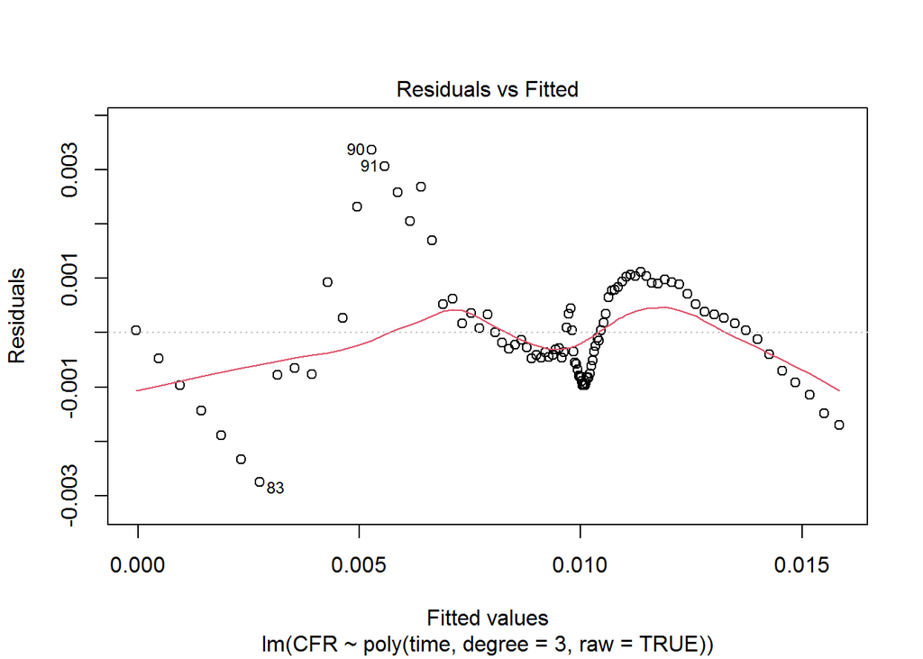

```r
russiaresid = plot(russpoly.model,1)
```

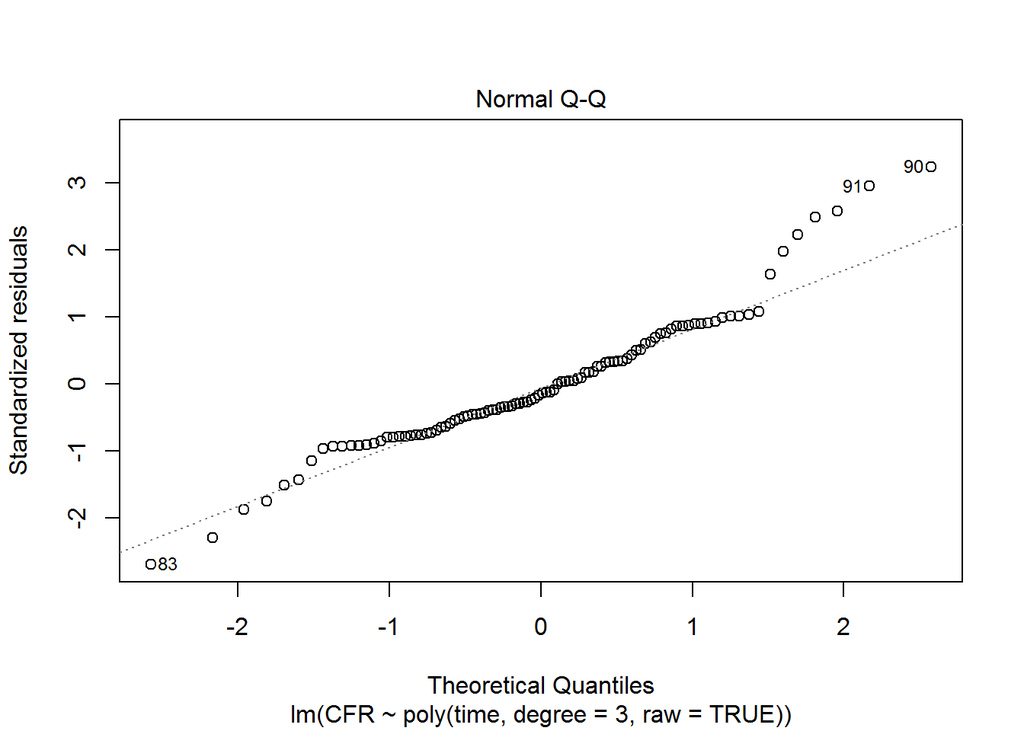

```r
russiaqq = plot(russpoly.model,2)
```

##Turkey Plots

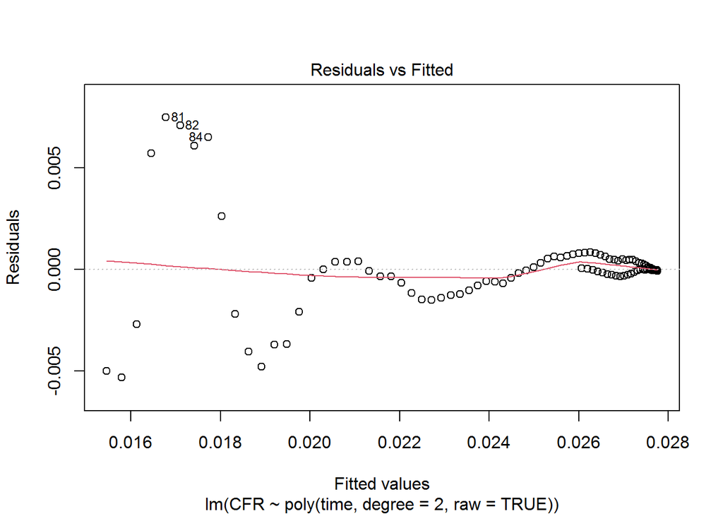

```r
turkeyresid = plot(turkpoly.model,1)
```

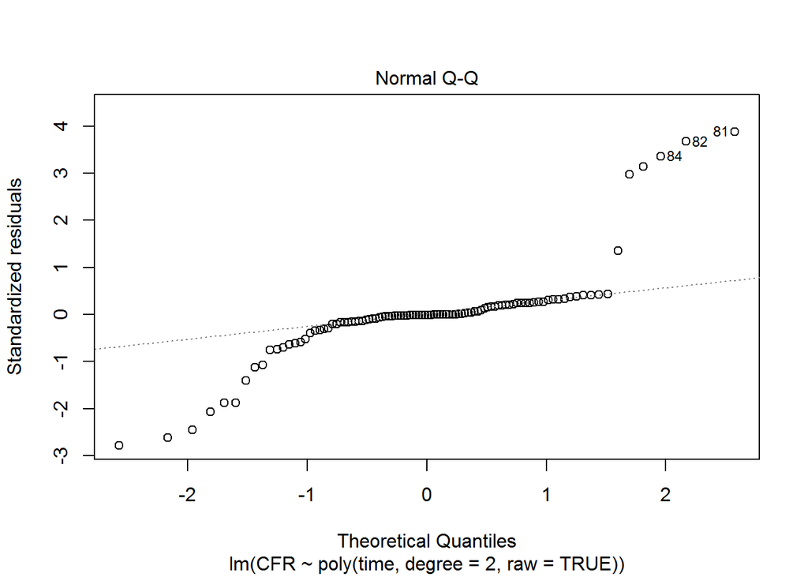

```r
turkeyqq = plot(turkpoly.model,2)
```

##Pakistan Plots

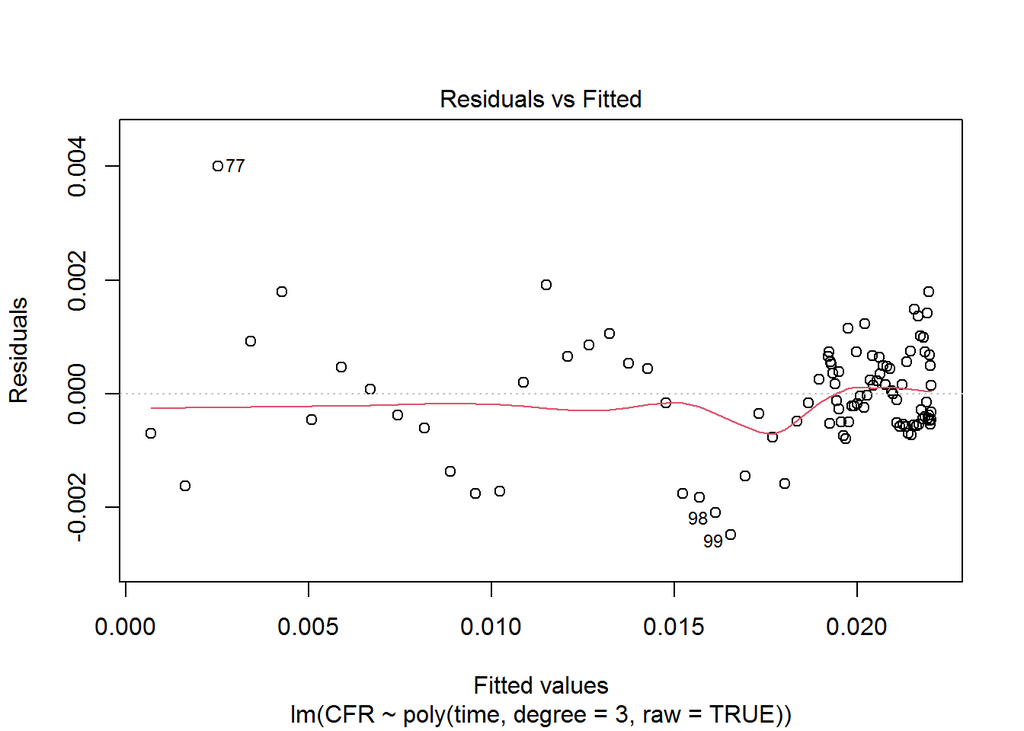

```r
pakistanresid = plot(pakpoly.model,1)
```

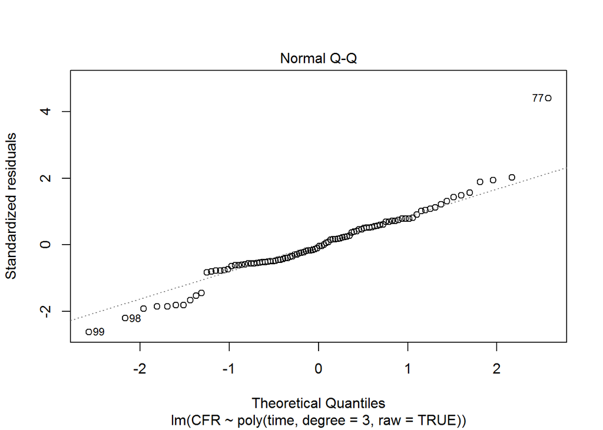

```r
pakistanqq = plot(pakpoly.model,2)
```

##Egypt Plots

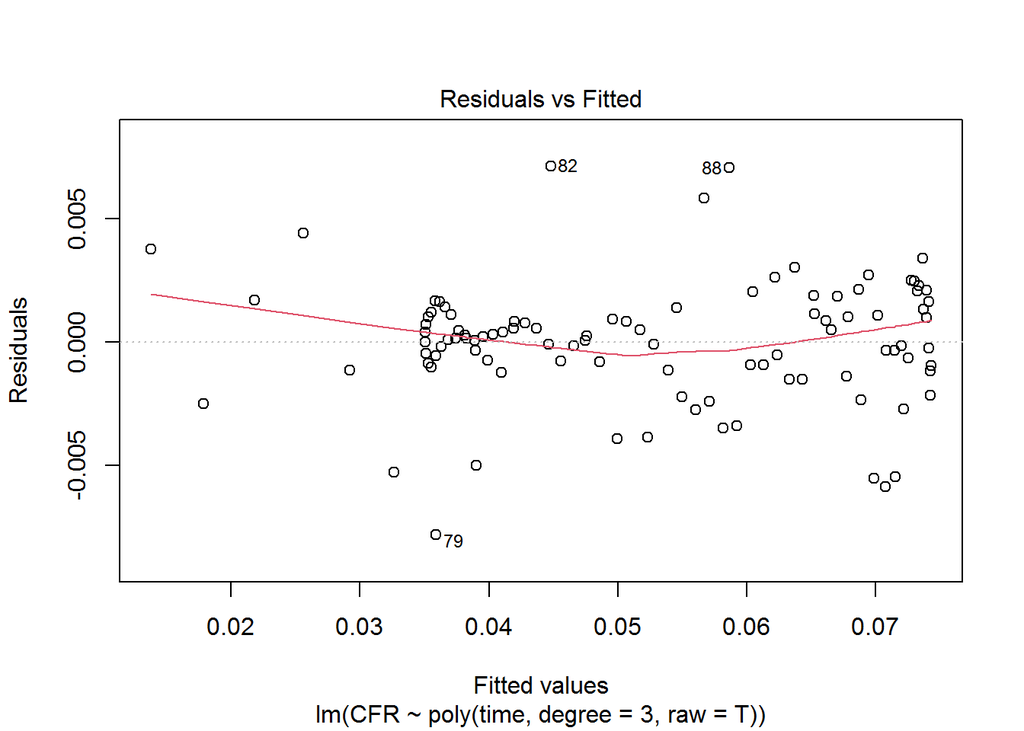

```r
egyptresid = plot(modegypt3,1)
```

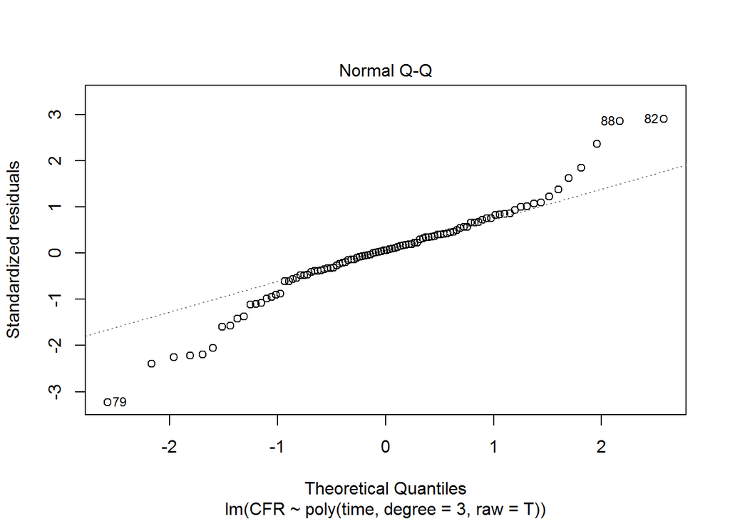

```r
egyptqq = plot(modegypt3,2)
```

##China Plots

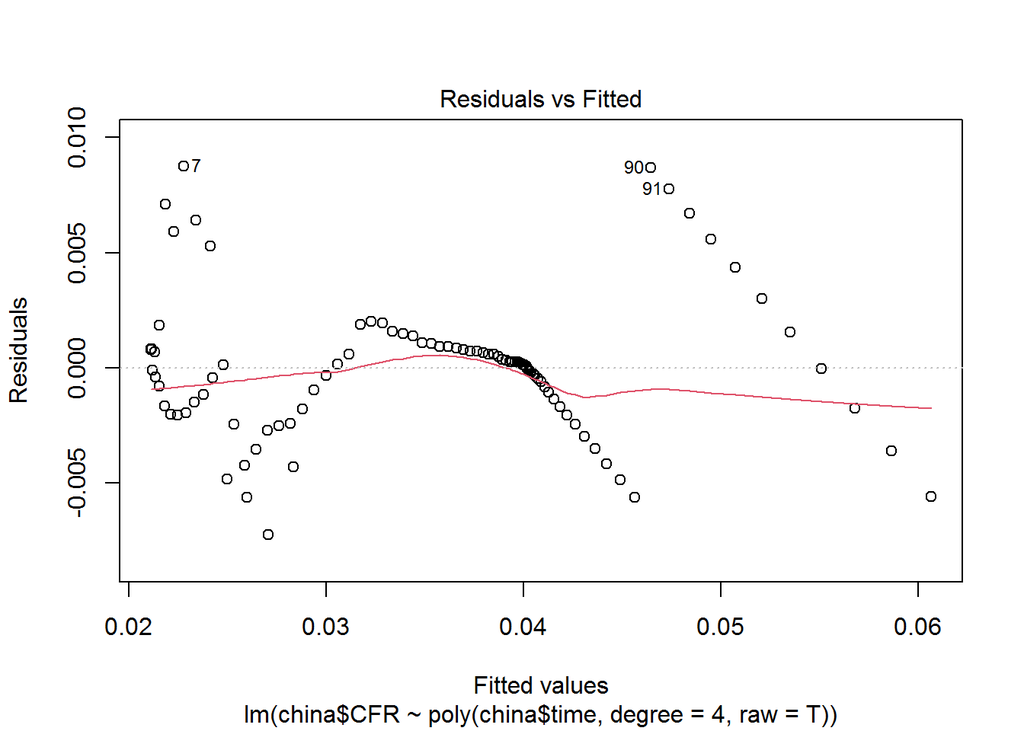

```r
chinaresid = plot(modchina2,1)
```

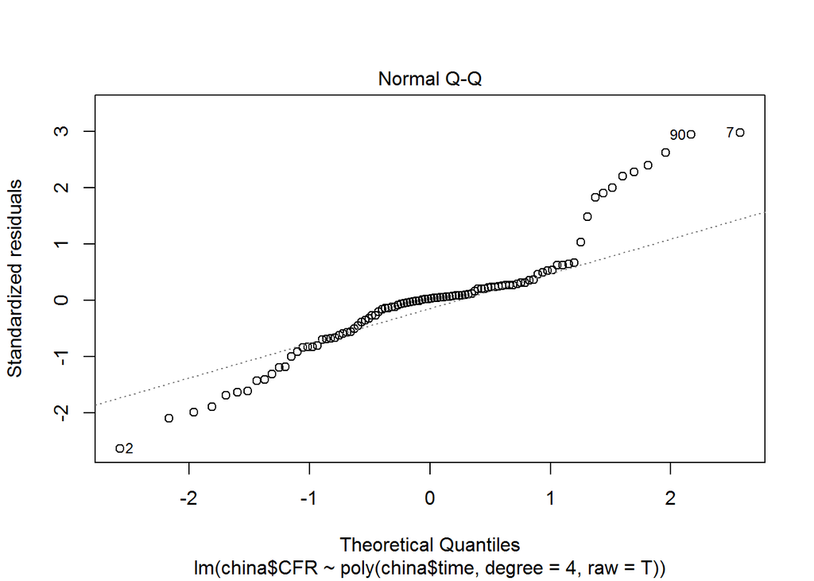

```r
chinaqq = plot(modchina2,2)
```

##Japan Plots

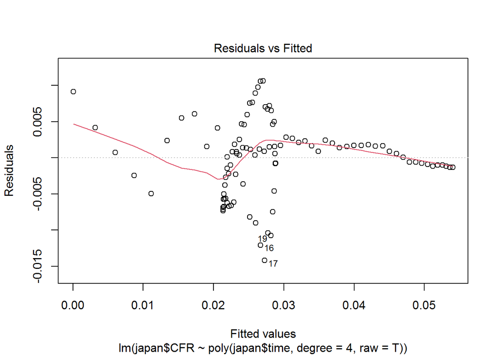

```r
japanresid = plot(modjapan2,1)
```

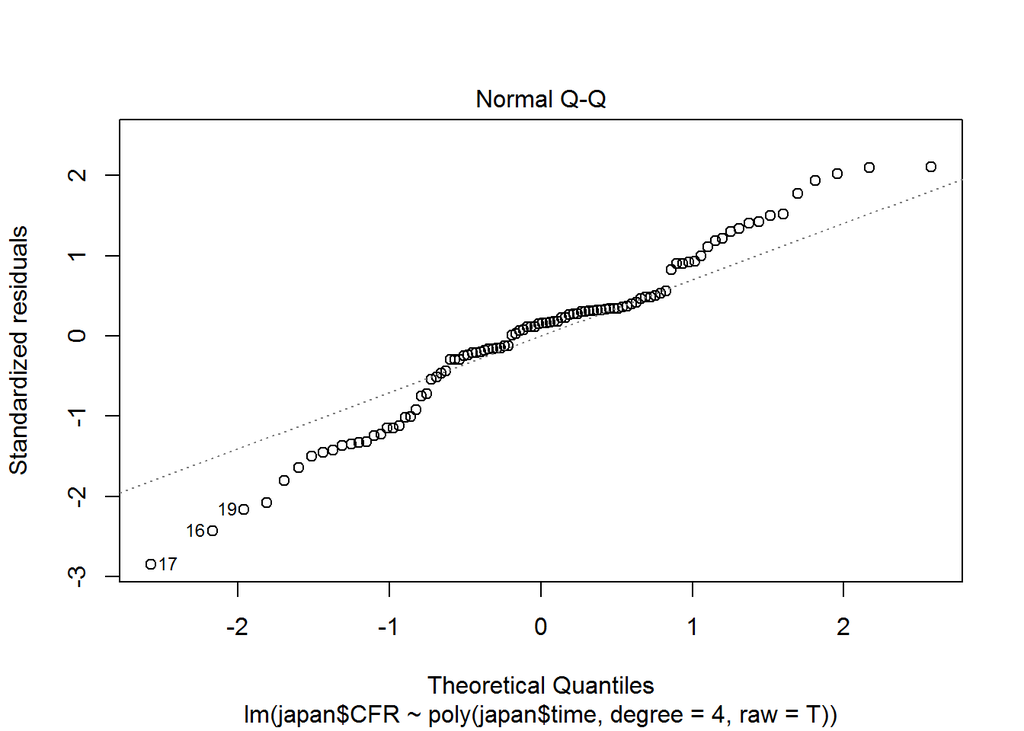

```r
japanqq = plot(modjapan2,2)
```

##ANOVA Plots

```r
binddata = rbind(nigeria,ethiopia,usa,brazil,india,indonesia,russia,turkey,pakistan,egypt,china,japan)

fit0 <- lm(CFR ~ poly(time, 3), data = binddata)
fit1 <- lm(CFR ~ poly(time, 3)*Country, data = binddata)

anova(fit0,fit1)
```

```
## Analysis of Variance Table
##
## Model 1: CFR ~ poly(time, 3)
## Model 2: CFR ~ poly(time, 3) * Country
##   Res.Df     RSS Df Sum of Sq      F    Pr(>F)
## 1   1196 0.48026
## 2   1152 0.01970 44   0.46057 612.15 < 2.2e-16 ***
## ---
## Signif. codes:  0 '***' 0.001 '**' 0.01 '*' 0.05 '.' 0.1 ' ' 1
```

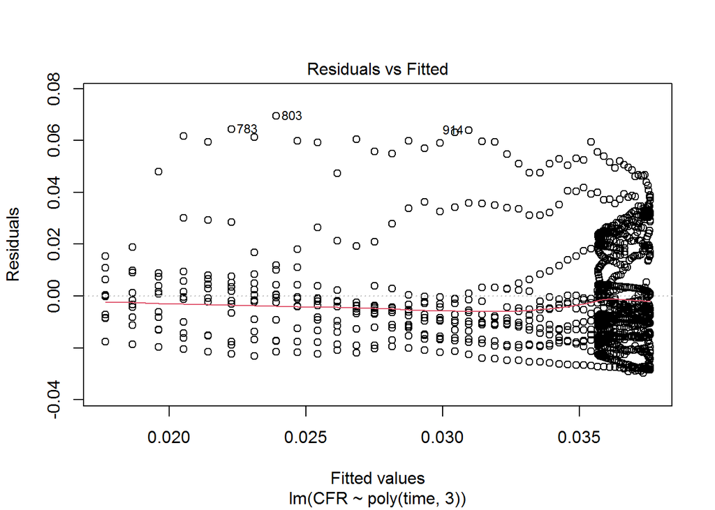

```r
plot(fit0,1)
```

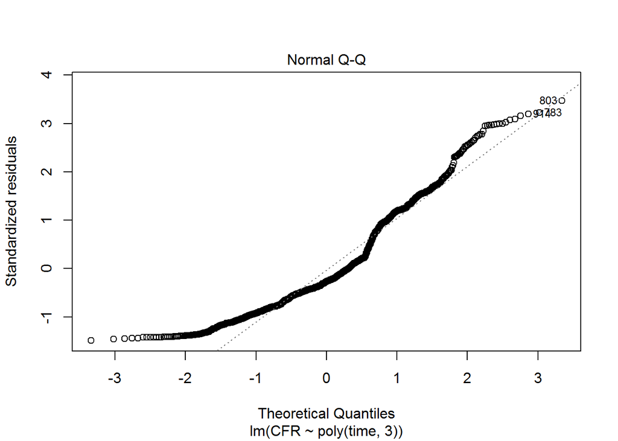

```r
plot(fit0,2)
```

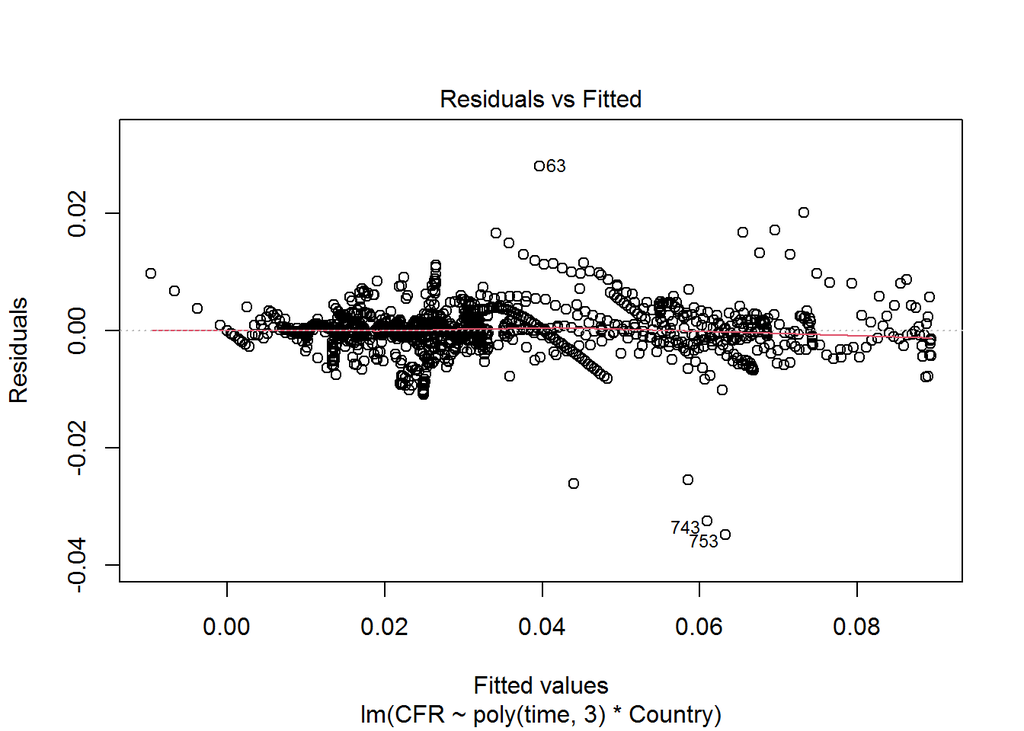

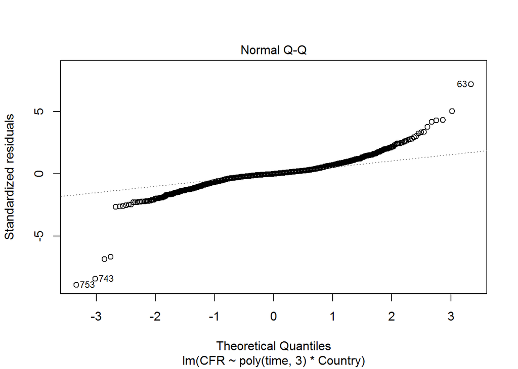

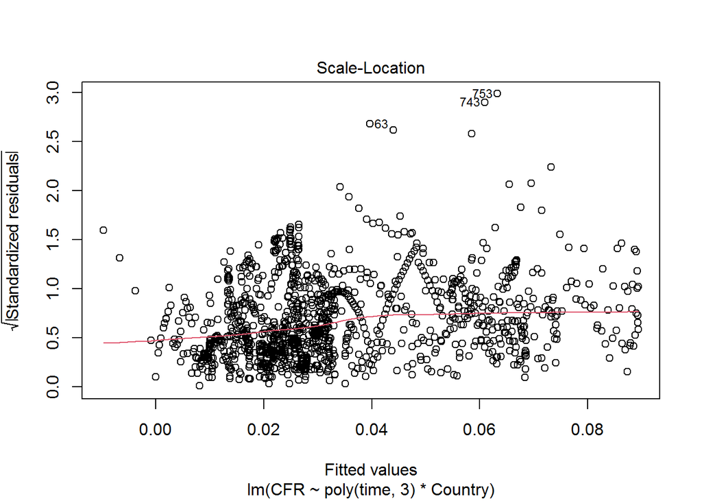

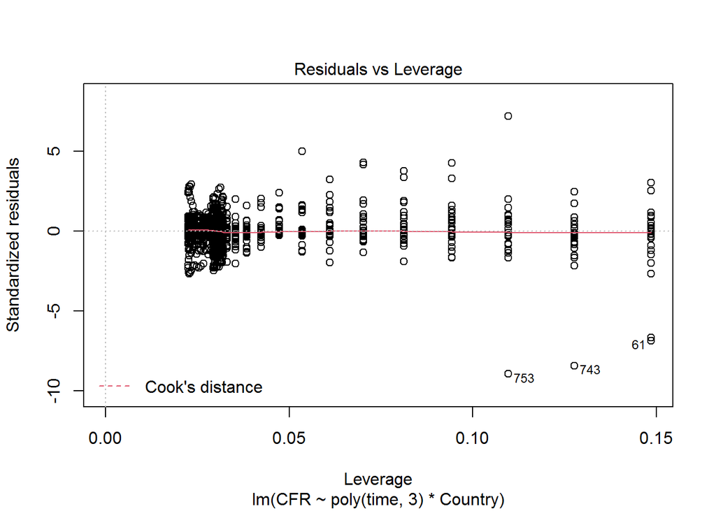

```r
plot(fit1)
```

# Conclusion

This report aimed to investigate how Case Fatality Rate (CFR) for COVID-19 changes across time for 12 of the most populated countries in the world (2 most populated countries per WHO region), specifically over the first hundred days after the number of cumulative cases hits 100. Through a series of statistical analysis, this report was able to analyze the hypothesis stated earlier.

It was hypothesized that the trends of CFR will vary significantly across these countries. The results of this report matches with the initial hypothesis. Through fitting the 12 observed countries’ CFR across time, a variety of regressions were chosen that fits the data the best. These polynomial regressions vary in correlation and degree of polynomials, which visually supports the hypothesis that CFR across time will be different for the countries.

In order to be more specific and explore beyond the big picture, comparing the country’s regression lines side by side informs the difference between countries’ CFR over time. The use of simultaneous confidence bands, which shows the 95% confidence interval across the whole regression line, appears that even though some countries do share a similar trend and overlaps, the majority of regressions were very different from one another. Hence, once again proving CFR trends over time is different for each country.

Looking at these regressions may reflect how countries are able or not able to react in controlling the virus. It is observed that most CFR trends are fluctuating across the timeframe. A drop after a peak might be due to the implementation of a certain policy or a country gaining better knowledge on how to contain and treat the virus. While an increase after a trough may be hints of hitting medical capacity or loosening of policies. There are many external factors and reasons to explore beyond numbers of COVID cases and deaths. These are all topics that can be delved deeper in further and more complicated analysis, however are all mere guesses at the current analysis.

The answer to the question of interest can be described as resounding and clear. However, it is important to note that this topic of interest has its own flaws and concerns to consider when interpreting the results. In terms of the dataset itself, the prevalence of reported cases and deaths varies between countries. This may be due to socioeconomic, political and cultural differences in each country. The number of observations for each country is limited, which amplifies the variance caused by outliers. Forming the question of interest was also based on a lot of logical assumptions that may not be statistically or scientifically true.

As the question of interest states, this report hopes to discover if there are significant differences in CFR over the first 100 days over a 100 cases. The regression lines for each country are in no intention to be predictive, rather to be a reflection of a specific trend during a specific time. The choice of countries and the choice of the timeframe are all factors to be aware of when interpreting the regressions. Unfair comparisons between countries may be made, for example a country that has a later time frame because of reaching hundred cases later may have better knowledge on the virus than countries that were affected earlier.

Overall, this report has been conclusive while assessed along with limitations. For further research, the reasons behind the trend can be explored, which could branch into a multitude of topics in politics, culture and science.

# References

Community mitigation framework. (2021, February 16). Retrieved March 05, 2021, from https://www.cdc.gov/coronavirus/2019-ncov/community/community-mitigation.html Howard, J., Huang, A., Li, Z., Tufekci, Z., Zdimal, V., Westhuizen, H., . . . Rimoin, A. (2021, January 26). An evidence review of face masks against COVID-19. Retrieved March 05, 2021, from https://www.pnas.org/content/118/4/e2014564118 Sorci, G., Faivre, B., & Morand, S. (2020, November 03). Explaining among-country variation IN COVID-19 case fatality rate. Retrieved March 05, 2021, from https://www.nature.com/articles/s41598-020-75848-2#citeas Tadiri, C. P., Gisinger, T., Kautzy-Willer, A., Kublickiene, K., Herrero, M. T., Raparelli, V., Pilote, L., Norris, C. M., & GOING-FWD Consortium (2020). The influence of sex and gender domains on COVID-19 cases and mortality. CMAJ : Canadian Medical Association journal = journal de l’Association medicale canadienne, 192(36), E1041–E1045. https://doi.org/10.1503/cmaj.200971 World Health Organization. (2021, March 1) WHO press conference on coronavirus disease (COVID-19) [Interview Transcript]. Retrieved from https://www.who.int/multi-media/details/who-press-conference-on-coronavirus-disease-(covid-19)---1-march-2021 Used codes on confidence interval bands : https://stats.stackexchange.com/questions/231059/compare-the-statistical-significance-of-the-difference-between-two-polynomial-re